# Resumen de los análisis llevados a cabo para buscar genes regulados por metilación

# Introducción

Este documento contiene un breve resumen de los análisis realizados con los datos proporcionados, así como con datos publicos obtenidos de GEO y TCGA para encontrar genes regulados por metilación.

Los análisis se describen con mayor detalle en otros documentos como

- AnalysisReport-1_HeuristicMethod.pdf centrado en el método heurístico y
- AnalysisReport-2-L-Shape_Selection_Pipeline.pdf centrado en el proceso de análisis de principio a fin usando tres métodos distintos que se describen a continuación.

Los métodos utilizados para seleccionar genes en L han sido:

## Clasificación, puntuación y parámetros

Cada método de hecho realiza dos cosas:

1. Clasifica los genes como “L” o no “L”
2. Les asigna algún tipo de puntuación, que puede ser el coeficiente de correlación (Naïf) la información múua condicional mínima (CMI) o la suma de las puntuaciones de cada punto según su posición en la gradilla (Heurístico).

El resultado de la clasificación y, en el caso del método heurístico, el “score” del gen, depende de, para cada método, de un conjunto de parámetros. Si éstos cambian, cambiara el número de genes seleccionados y / o la puntuación del gen.

Idealmente podríamos utilizar un proceso de optimización por ejemplo para buscar los parámetros que proporcionen máxima sensibilidad y especificidad en la selección. Esto sin embargo se ve dificultado por el hecho de que cuesta disponer de genes que representen auténticos positivos o auténticos negativos, por lo que, de momento nos hemos basado en una selección manual de los parámetros

## El pipeline de análisis

- El análisis se ha llevado a cabo utilizando los pasos descritos en el documento `AnalysisReport-2-L-Shape_Selection_Pipeline.pdf` que se enumeran brevemente a continuación
1. Lectura de los datos y comprobación de su idoneidad para el análisis
2. Aplicación de los tres métodos descritos a cada pareja de matrices Expresión-metilación.  
   1.1. Fijación de parámetros  
   1.2. Selección (y puntuación) de los genes  
   1.3. Creación de tablas y gráficos con los resultados obtenidos.
3. Anotación (localización de la posición) de los genes seleccionados sobre el genoma.
4. Creación de un gráfico que muestre cromosoma a cromosoma, para cada método y cada dataset la posición de los genes identificados como “L”.

# Los datos para el estudio

En este estudio se han utilizado tres datasets:

```
## DA Microarray data :  11359 30
```

```
## DA Methylation data:  11359 30
```

```
## GEO Microarray data :  11191 25
```

```
## GEO Methylation data:  11191 25
```

```
## TCGA Microarray data :  11788 223
```

```
## TCGA Methylation data:  11788 223
```

# Resultados

## Selección de los datos

El análisis se ha llevado a cabo con los tres pares de matrices de datos descritos en el apartado anterior.

## Parámetros del análisis

Para la selección de genes se ha usado los criterios siguientes

- Método *Naive*: Se ha clasificado como “L” los genes con una correlación de Spearman negativa ($r\leq -0.5$) y un p-valor (FDR) ajustado por el método BH de $p\leq 0.25$.
- Método *CMI*: Se han clasificado como L los genes que verifican que
  - EL cociente entre la Información mútua condicional (CMI) en cualquier valor entre 0 y 1 y el valor de la CMI en 0 es inferior a r<0.25.
  - El valor mínimo cMI(0) super un cierto umbral (aquí 0.1).
- Método *Heurístico*
  - Para decidir si un gen se clasifica como L se ha usado las siguientes tablas de valres mínimos/máximos: una para los datos de DA o de GEO y otra para los de TCGA.
  - `Reqpercentages`: Porcentaje de genes que deben contener **como mínimo** las celdas de “L”: (1,1), (2, 1), (3,1), (3,2), (3,3) y **como maximo** las celdas no-L (1,2), (1,3), (2,2), (2,3)
  - `theWeightMifL`: Pesos para puntuar cada punto de la celda si es una L.
  - `theWeightMifNonL`: Pesos para puntuar cada punto de la celda si NO es una L.

### Parámetros para la selección en muestras pequeñas: (GEO o DA)

```
##      [,1] [,2] [,3]
## [1,]   10   20    1
## [2,]    5   40   20
## [3,]    0    5   10
```

```
##      [,1] [,2] [,3]
## [1,]    3    6    0
## [2,]    2   12    6
## [3,]    0    2    3
```

```
## Informative. Not used in calculations, because it is computed within the loop
```

```
##      [,1] [,2] [,3]
## [1,]    2   -2  -25
## [2,]    1    0   -2
## [3,]    1    1    2
```

```
##      [,1] [,2] [,3]
## [1,]    0   -2  -25
## [2,]    0    0   -2
## [3,]    0    0    0
```

### Parámetros para la selección en muestras grandes: (TCGA)

```
##      [,1] [,2] [,3]
## [1,]    4   20    5
## [2,]    1   40   20
## [3,]    0    1    4
```

```
## Informative. Not used in calculations, because it is computed within the loop
```

```
## [1] 223
```

```
##      [,1] [,2]  [,3]
## [1,]    2   -2 -44.6
## [2,]    1    0  -2.0
## [3,]    1    1   2.0
```

```
##      [,1] [,2]  [,3]
## [1,]    0   -2 -44.6
## [2,]    0    0  -2.0
## [3,]    0    0   0.0
```

## Resultados

### Tablas de resúmenes de resultados

Los resultados de aplicar los tres métodos a cada dataset se han reunido en tres archivos (uno por dataset):

- `LshapeScoresDA.csv`
- `LshapeScoresGEO.csv`
- `LshapeScoresTCGA.csv`

que contienen las columnas siguientes:

- `r..Sp.`: Coefciende de correlación de Spearman
- `p..Sp.`: P-valor para el test de significación de correlación
- `adj.Spear.Pval`: -valor ajustado
- `distCor`: Distancia de correlación. Otra forma de medir la correlación que toma sólo valores positivos
- `SigNegCorr`: TRUE o FALSE segun si se cumplen los criterios definidos para el método Naive
- `cMI_min`: Información mutua condicional mínima
- `t_opt`: Punto en que CMI pasa de decrecer a crecer: (¿Puede considerarse el punto a partir del que el gen está metilado?)
- `ratio`: Razon de CMI en el valor cero (si es menor que el valor fijado entonces el gen puede tener forma de L)
- `meth_regulated`: TRUE o FALSE segun si se cumplen los criterios definidos para el método CMI
- `logicSc`: TRUE o FALSE segun si se cumplen los criterios definidos para el método Heuristic
- `numericSc`; Puntuación obtenida por el metodo heurístico.

Los archivos de resultados se presentan en orden alfabético pero si por ejemplo los ordenamos por el coeficiente de correlación en orden ascendente tendríamos:

```
##         r..Sp.    p..Sp. adj.Spear.Pval distCor SigNegCorr cMI_min t_opt
## BST2   -0.8652 6.905e-10      5.800e-06  0.8945       TRUE 0.15036  0.37
## RIPK3  -0.8581 1.355e-09      5.800e-06  0.8361       TRUE 0.06664  0.34
## EVPL   -0.8567 1.532e-09      5.800e-06  0.8587       TRUE 0.11460  0.45
## PYCARD -0.8469 3.626e-09      9.574e-06  0.8474       TRUE 0.16767  0.54
## ZNF420 -0.8452 4.214e-09      9.574e-06  0.8332       TRUE 0.07968  0.30
## TNS4   -0.8287 1.557e-08      2.948e-05  0.8253       TRUE 0.06766  0.23
##         ratio meth_regulated logicSc numericSc
## BST2   0.2467           TRUE    TRUE        41
## RIPK3  0.1332           TRUE    TRUE        38
## EVPL   0.3750          FALSE   FALSE       -16
## PYCARD 0.2999          FALSE    TRUE        32
## ZNF420 0.1453           TRUE    TRUE        47
## TNS4   0.1467           TRUE   FALSE         0
```

```
##           r..Sp.    p..Sp. adj.Spear.Pval distCor SigNegCorr   cMI_min
## STRN4    -0.8146 7.175e-07        0.00803  0.7324       TRUE 2.264e-04
## MYOZ1    -0.7369 2.653e-05        0.07480  0.4879       TRUE 9.414e-03
## DEXI     -0.7367 2.674e-05        0.07480  0.7131       TRUE 1.195e-04
## FLJ30655 -0.7262 3.968e-05        0.08296  0.6570       TRUE 1.095e-04
## FER      -0.7215 4.689e-05        0.08296  0.7445       TRUE 2.353e-03
## GBF1     -0.7138 6.150e-05        0.08296  0.6854       TRUE 7.838e-05
##          t_opt  ratio meth_regulated logicSc numericSc
## STRN4     0.04 0.2064          FALSE   FALSE         0
## MYOZ1     0.85 0.2910          FALSE   FALSE       -50
## DEXI      0.03 0.3174          FALSE   FALSE         0
## FLJ30655  0.03 0.3418          FALSE   FALSE         0
## FER       0.06 0.1553          FALSE   FALSE         0
## GBF1      0.02 0.5347          FALSE   FALSE         0
```

```
##           r..Sp. p..Sp. adj.Spear.Pval distCor SigNegCorr cMI_min t_opt
## BST2     -0.8184      0              0  0.8010       TRUE 0.07227  0.57
## FAM50B   -0.7944      0              0  0.8290       TRUE 0.02321  0.61
## CLDN15   -0.7840      0              0  0.8236       TRUE 0.05685  0.45
## ZNF549   -0.7759      0              0  0.7838       TRUE 0.06523  0.50
## CHFR     -0.7757      0              0  0.7575       TRUE 0.08564  0.29
## PLA2G12B -0.7743      0              0  0.8417       TRUE 0.03684  0.66
##            ratio meth_regulated logicSc numericSc
## BST2     0.18678           TRUE   FALSE    -195.2
## FAM50B   0.08511           TRUE   FALSE    -176.0
## CLDN15   0.12528           TRUE    TRUE     287.0
## ZNF549   0.18680           TRUE    TRUE      16.2
## CHFR     0.20336           TRUE   FALSE    -241.2
## PLA2G12B 0.08794           TRUE   FALSE    -463.6
```

### Genes considerados en forma de L

Las tablas de resultados tan sólo generan un valor binario para el método heurístico, pero fijando valores de corte para los métodos naïve y cMI es imediato obtener lista de valores similares para éstos métodos. Por ejemplo definiremos “Regulado por metilación”

```
## [1] 8440
```

```
##       DA_naive         DA_CMI   DA_heuristic      GEO_naive        GEO_CMI
##            351            592            145             59            165
##  GEO_heuristic     TCGA_naive       TCGA_CMI TCGA_heuristic
##             35            138            226            578
```

Esto nos permite ver con facilidad los genes en común en cada set entre distintos métodos y los genes seleccionados por cada método entre datasets.

[figure not shown]

### El gen ZBTB18

Este gen reviste especial interes para los investigadores por lo que podemos resaltar aquí los resultados obtenidos para él.

Empezando por los gráficos resulta claro que no esperaremos que el algoritmo àra seleccionar formas de L lo seleccione pero que si lo haga la correlación negativa, como así resulta ser.

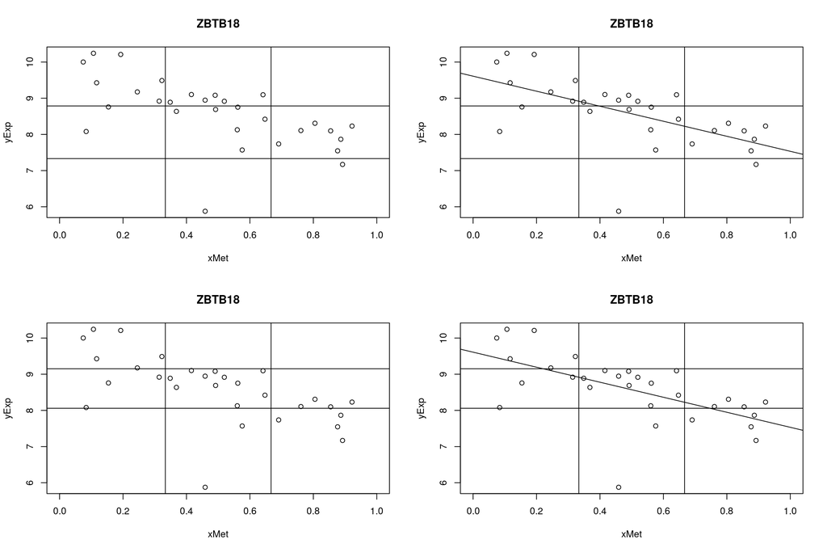

Si miramos las puntuaciones obtenidas queda claro que tan sólo la correlación negativa retendría este gen.

```
## Results for gene ZBTB18 based on selection by correlation
```

```
##         r..Sp.    p..Sp. adj.Spear.Pval distCor SigNegCorr
## ZBTB18 -0.6779 3.862e-05       0.006451  0.6888       TRUE
```

```
## Results for gene ZBTB18 based on selection by CMI
```

```
##        cMI_min t_opt  ratio meth_regulated
## ZBTB18  0.1561  0.57 0.3587          FALSE
```

```
## Results for gene ZBTB18 based on selection by Heuristic Methd
```

```
##        logicSc numericSc
## ZBTB18   FALSE       -26
```

### Gráficos

El objetivo del análisis es encontrar genes regulados por metilación y esto se ha concretado en buscar aquellos que tengan forma de L o se sitúen en una diagonal.  
Una forma La forma de comprobarlo es visualizando el diagrama de dispersión.

Los archivos:

- `DAExprAllScores.pdf`
- `GEOLGenesScores.pdf`
- `TCGALGenesScores.pdf`

contienen dichos gráficos.

## Anotacion de los genes en los cromosomas

Una vez seleccionada una lista de genes (es decir los que se clasifican “TRUE”) para cada dataset y cada método se han representado los genes seleccionados sobre el cromosoma que los contiene, junto con las coordenadas de las islas CpG y de los sitios hipersensitivos de las DNAsas.

Los archivos que contienen los gráficos se denominan `genePositionstcXXXyyy.pdf` donde XXX indica el método e `yyy`el dataset es decir se encuentran en los archivos

- `genePositionstcNaiveDA.pdf`
- `genePositionstcCMIDA.pdf`
- `genePositionstcHeuristicDA.pdf`
- `genePositionstcNaiveGEO.pdf`
- `genePositionstcCMIGEO.pdf`
- `genePositionstcHeuristicGEO.pdf`
- `genePositionstcNaiveTCGA.pdf`
- `genePositionstcCMITCGA.pdf`
- `genePositionstcHeuristicTCGA.pdf`